# Problem Set 1

Adrienne Scott

February 19, 2018

### Section 1 - Initial set up

1 - Load the Democracy dataset into memory as a dataframe. Use the read.csv function, and the stringsAsFactors = FALSE option. Note that missing values are indicated by “.” in the data. Find the option in read.csv that controls the string used to indicate missing values.

```r
democracy <- read.csv(file = "democracy.csv", header=TRUE, na.strings=".", stringsAsFactors = FALSE)
```

### Section 2 - Initial data exploration

1 - Report summary statistics (means and medians, at least) for all variables.

```r
summary(democracy)
```

```
##     COUNTRY         CTYNAME             REGION               YEAR
##  Min.   :  1.00   Length:4126        Length:4126        Min.   :1951
##  1st Qu.: 39.00   Class :character   Class :character   1st Qu.:1965
##  Median : 71.00   Mode  :character   Mode  :character   Median :1974
##  Mean   : 70.18                                         Mean   :1973
##  3rd Qu.:103.00                                         3rd Qu.:1983
##  Max.   :135.00                                         Max.   :1990
##
##     BRITCOL            CATH           CIVLIB           EDT
##  Min.   :0.0000   Min.   : 0.00   Min.   :1.000   Min.   : 0.030
##  1st Qu.:0.0000   1st Qu.: 0.00   1st Qu.:2.000   1st Qu.: 2.214
##  Median :0.0000   Median :22.25   Median :5.000   Median : 4.540
##  Mean   :0.2433   Mean   :37.20   Mean   :4.076   Mean   : 4.853
##  3rd Qu.:0.0000   3rd Qu.:84.00   3rd Qu.:6.000   3rd Qu.: 7.085
##  Max.   :1.0000   Max.   :99.00   Max.   :7.000   Max.   :12.810
##                                   NA's   :1727    NA's   :1226
##      ELF60             GDPW           MOSLEM           NEWC
##  Min.   :0.0000   Min.   :  480   Min.   : 0.00   Min.   :0.0000
##  1st Qu.:0.1000   1st Qu.: 2458   1st Qu.: 0.00   1st Qu.:0.0000
##  Median :0.3700   Median : 6012   Median : 0.50   Median :0.0000
##  Mean   :0.3995   Mean   : 8877   Mean   :19.74   Mean   :0.4561
##  3rd Qu.:0.6900   3rd Qu.:12608   3rd Qu.:16.20   3rd Qu.:1.0000
##  Max.   :0.9300   Max.   :37903   Max.   :99.90   Max.   :1.0000
##  NA's   :542
##       OIL             POLLIB          REG              STRA
##  Min.   :0.0000   Min.   :1.00   Min.   :0.0000   Min.   :0.0000
##  1st Qu.:0.0000   1st Qu.:2.00   1st Qu.:0.0000   1st Qu.:0.0000
##  Median :0.0000   Median :3.00   Median :0.0000   Median :0.0000
##  Mean   :0.1001   Mean   :3.86   Mean   :0.3987   Mean   :0.3752
##  3rd Qu.:0.0000   3rd Qu.:6.00   3rd Qu.:1.0000   3rd Qu.:1.0000
##  Max.   :1.0000   Max.   :7.00   Max.   :1.0000   Max.   :5.0000
##                   NA's   :1727
```

2 - Create a histogram for political liberties in which each unique value of the variable is in its own bin.

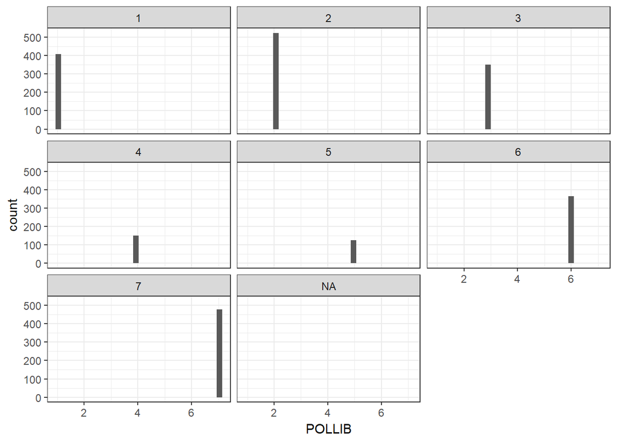

```r
ggplot(democracy, aes(POLLIB)) +
  geom_histogram() +
  theme_bw()+
  facet_wrap(~POLLIB)
```

3 - Create a histogram for GDP per capita.

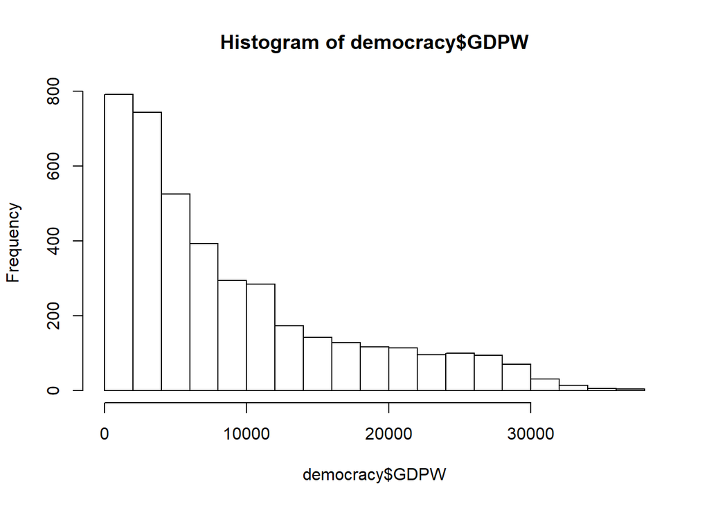

```r
hist(democracy$GDPW) +
  theme_bw()
```

4 - Create a histogram for log GDP per-capita. How is this histogram different than the one for GDP per capita when it was not logged?

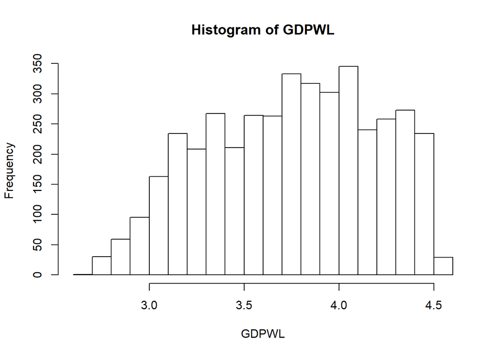

```r
GDPWL <- log10(democracy$GDPW)
hist(GDPWL) +
  theme_bw()
```

The original histogram presents the data in a manner which you can see that it is has a logarithmic pattern that gradually decreases. However, by placing the variable on a logarithmic scale, the pattern is removed and you are able to see the marginal rates of change.